# ¿Existe una relación entre las defunciones por enfermedad respiratoria, el tiempo meteorológico y la cantidad de zonas verdes?

Claudia Valentín, Nisrine Fariss, Jacinto Javier Pérez

2023-12-10

# Indice de contenidos

1. Introducción
2. Objetivos
3. Conjunto de datos
4. Desarrollo y Resultados
5. Conclusiones finales

## 1.Introducción

La superficie de zonas verdes en España y en el mundo han ido disminuyendo, siendo sustiyuendo estas superficies por construcción de infraestructuras, carreteras, desarollo urbano, etc…

Estas zonas verdes ayudan a la eliminacion de gases atmosfericos, por lo que al eliminarlas o reducirlas percute en nuestra salud y ademas la cantidad de estas zonas influyen en la regulación del clima.

## 2.Objetivos

El objetivo principal de nuestro proyecto es determinar una posible relación entre las defunciones por enfermedades respiratorias y el medio ambiente.

Tambien vamos a comparar los resultados con la cantidad de centros de salud para contrastar si tambien es un problema por falta de medios sanitarios o solo medioambientales

## 3.Conjunto de datos

Hemos recogido datos de bases de datos diferentes, entre ellas encontramos la aemet, el ine, el ministerio de sanidad y el diario AS. También hemos recurrido a varios articulos geograficos y webs oficiales de ciertos ayuntamientos para completar la busqueda de datos de zonas verdes.

Vamos a trabajar con ellos en el formato .xlsx

## 4.Desarrollo y Resultados

En primer lugar, vamos a realizar una exposición principal de todos los datos recabados para luego modificarlos y trabajar con ellos.

**Importación de librerias**

```r
library(readxl)
library(dplyr)
library(tidyverse)
library(ggplot2)
library(climaemet)
library(lubridate)
library(htmltools)
library(DT)
library(mapSpain)
library(sf)
library(gridExtra)
```

### 4.1Datos de defunciones por enfermedades respiratorias

|  | Provincia | defunciones |
| --- | --- | --- |
| 1 | Nacional | 42423 |
| 2 | Albacete | 399 |
| 3 | Alicante/Alacant | 1385 |
| 4 | Almería | 518 |
| 5 | Araba/Álava | 250 |
| 6 | Asturias | 1215 |
| 7 | Ávila | 228 |
| 8 | Badajoz | 840 |
| 9 | Balears, Illes | 734 |
| 10 | Barcelona | 4526 |

[output cut: 154 more lines]

#### Datos de defunciones por enfermedades respiratorias total por Provincia

```r
defuncion_resp_total<-defuncion_resp %>%
  slice(2:53)%>%
  select(1,2)
datatable(defuncion_resp_total)
```

|  | Provincia | defunciones |
| --- | --- | --- |
| 1 | Albacete | 399 |
| 2 | Alicante/Alacant | 1385 |
| 3 | Almería | 518 |
| 4 | Araba/Álava | 250 |
| 5 | Asturias | 1215 |
| 6 | Ávila | 228 |
| 7 | Badajoz | 840 |
| 8 | Balears, Illes | 734 |
| 9 | Barcelona | 4526 |
| 10 | Bizkaia | 832 |

[output cut: 42 more lines]

#### Datos de defunciones por enfermedades respiratorias mujeres por Provincia

```r
defuncion_resp_mujeres<-defuncion_resp %>%
  slice(112:163)%>%
  select(1,2)%>%
  rename(defunciones_mujeres= 2)
datatable(defuncion_resp_mujeres)
```

|  | Provincia | defunciones_mujeres |
| --- | --- | --- |
| 1 | Albacete | 159 |
| 2 | Alicante/Alacant | 590 |
| 3 | Almería | 196 |
| 4 | Araba/Álava | 110 |
| 5 | Asturias | 531 |
| 6 | Ávila | 88 |
| 7 | Badajoz | 372 |
| 8 | Balears, Illes | 274 |
| 9 | Barcelona | 1933 |
| 10 | Bizkaia | 389 |

[output cut: 42 more lines]

#### Datos de defunciones por enfermedades respiratorias hombres por Provincia

```r
defuncion_resp_hombres<-defuncion_resp %>%
  slice(57:108)%>%
  select(1,2)%>%
  rename(defunciones_hombres= 2)
datatable(defuncion_resp_hombres)
```

|  | Provincia | defunciones_hombres |
| --- | --- | --- |
| 1 | Albacete | 240 |
| 2 | Alicante/Alacant | 795 |
| 3 | Almería | 322 |
| 4 | Araba/Álava | 140 |
| 5 | Asturias | 684 |
| 6 | Ávila | 140 |
| 7 | Badajoz | 468 |
| 8 | Balears, Illes | 460 |
| 9 | Barcelona | 2593 |
| 10 | Bizkaia | 443 |

[output cut: 42 more lines]

#### Histograma de defunciones por enfermedades respiratorias de hombres y mujeres por Provincia

```r
defuncion_resp_combinada <- inner_join(defuncion_resp_hombres, defuncion_resp_mujeres, by = "Provincia")
datatable(defuncion_resp_combinada)
```

|  | Provincia | defunciones_hombres | defunciones_mujeres |
| --- | --- | --- | --- |
| 1 | Albacete | 240 | 159 |
| 2 | Alicante/Alacant | 795 | 590 |
| 3 | Almería | 322 | 196 |
| 4 | Araba/Álava | 140 | 110 |
| 5 | Asturias | 684 | 531 |
| 6 | Ávila | 140 | 88 |
| 7 | Badajoz | 468 | 372 |
| 8 | Balears, Illes | 460 | 274 |
| 9 | Barcelona | 2593 | 1933 |
| 10 | Bizkaia | 443 | 389 |

[output cut: 42 more lines]

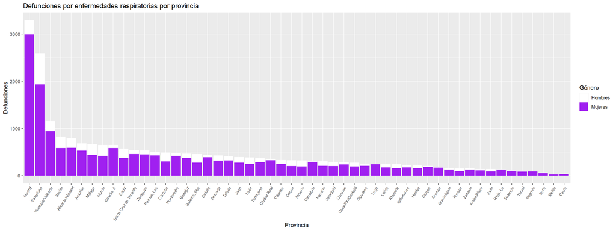

```r
ggplot(defuncion_resp_combinada, aes(x =reorder( Provincia, - defunciones_hombres))) +
  geom_bar(aes(y = defunciones_hombres, fill = "Hombres"), position = "dodge", stat = "identity") +
  geom_bar(aes(y = defunciones_mujeres, fill = "Mujeres"), position = "dodge", stat = "identity") +
  labs(title = "Defunciones por enfermedades respiratorias por provincia",
       x = "Provincia",
       y = "Defunciones",
       fill = "Género") +
  scale_fill_manual(values = c("Hombres" = "white", "Mujeres" = "purple"))+
  theme(axis.text.x = element_text(angle = 57, hjust = 1, size = 7))
```

### 4.2 Datos de la cantidad de zonas verdes por provincias Españolas

```r
zonas_verdes <- read_excel("zonas_verdes.xlsx")
datatable(zonas_verdes)
```

|  | Provincia | Población | Parques m²/hab |
| --- | --- | --- | --- |
| 1 | Araba/Álava | 246976 | 26.76 |
| 2 | León | 125317 | 24.11 |
| 3 | Madrid | 3182981 | 21 |
| 4 | Navarra | 649946 | 25 |
| 5 | Sevilla | 689434 | 11.27 |
| 6 | Valladolid | 299715 | 21.96 |
| 7 | Cantabria | 581641 | 10.62 |
| 8 | Lleida | 138144 | 10.1 |
| 9 | Zaragoza | 664938 | 9.02 |
| 10 | Gipuzkoa | 186370 | 18.24 |

[output cut: 38 more lines]

#### Mapa de la cantidad de zonas verdes m²/hab

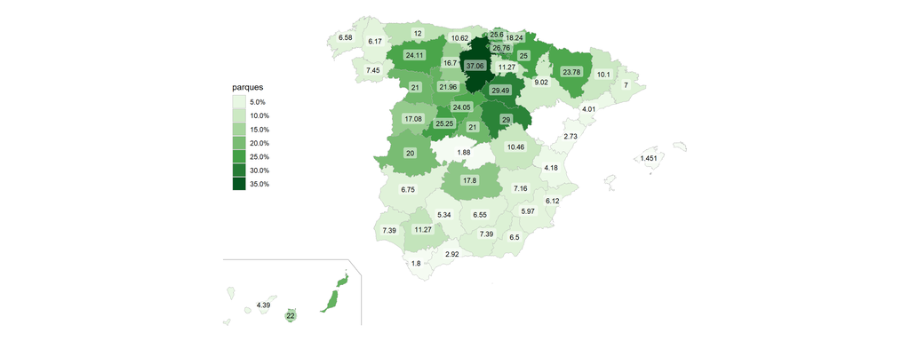

```r
Provs <- esp_get_prov()%>%
  rename("Provincia"=ine.prov.name)
provincias<-st_as_sf(inner_join(y=Provs, x= zonas_verdes, by="Provincia"))
Can <- esp_get_can_box()
ggplot(provincias) +
  geom_sf(aes(fill =`Parques m²/hab`),
    color = "grey70",
    linewidth = .3
  ) +
  geom_sf(data = Can, color = "grey70") +
  geom_sf_label(aes(label = `Parques m²/hab`),
    fill = "white", alpha = 0.5,
    size = 3,
label.size = 0
  ) +
  scale_fill_gradientn(
    colors = hcl.colors(15, "Greens", rev = TRUE),
    n.breaks = 10,
    labels = function(x) {
      sprintf("%1.1f%%", 1 * x)
    },
    guide = guide_legend(title = "parques")
  ) +
  theme_void() +
  theme(legend.position = c(0.1, 0.6))
```

### 4.3 Número de hospitales por provincia.

```r
datos <-read_excel("CNH_2021.xlsx")
conteo_por_provincia <- datos %>%
  group_by(Provincia) %>%
  summarize(Numero_Hospitales = n_distinct(`Nombre Centro`))
datatable(conteo_por_provincia)
```

|  | Provincia | Numero_Hospitales |
| --- | --- | --- |
| 1 | Albacete | 9 |
| 2 | Alicante/Alacant | 23 |
| 3 | Almería | 8 |
| 4 | Araba/Álava | 6 |
| 5 | Asturias | 25 |
| 6 | Badajoz | 19 |
| 7 | Balears, Illes | 24 |
| 8 | Barcelona | 136 |
| 9 | Bizkaia | 21 |
| 10 | Burgos | 8 |

[output cut: 42 more lines]

#### Gráfico de barras del número de hospitales por provincia

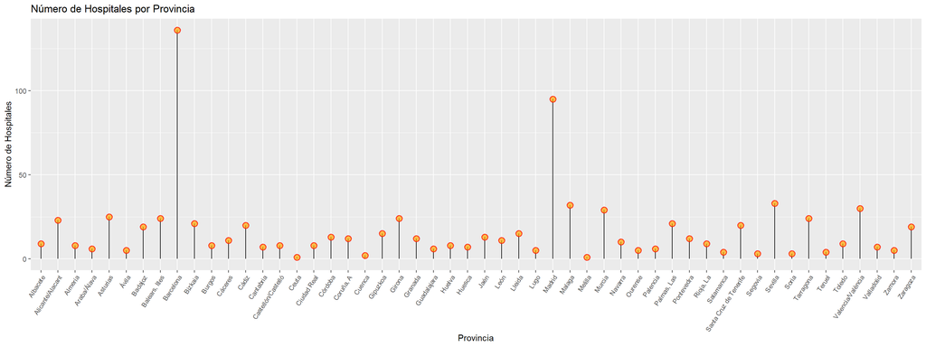

```r
ggplot(conteo_por_provincia, aes(x = Provincia, y = Numero_Hospitales)) +
  geom_segment(aes(x=Provincia, xend=Provincia, y=0, yend=Numero_Hospitales)) +
  geom_point( size=3, color="red", fill=alpha("orange", 0.3), alpha=0.7, shape=21, stroke=1) +
  labs(title = "Número de Hospitales por Provincia",
       x = "Provincia",
       y = "Número de Hospitales") +
  theme(axis.text.x = element_text(angle = 57, hjust = 1, size = 8))
```

### 4.4 Lluvias por provincia

```r
aemet_api_key("eyJhbGciOiJIUzI1NiJ9.eyJzdWIiOiJjbGF1ZGlhdmFsZ3VAZ21haWwuY29tIiwianRpIjoiMTU3MmFl….X2uwTqNh9qDeaoVJSlEgO4oCN_YpqRAVRlgxsV0BUtU",install=TRUE, overwrite = TRUE)
estaciones<- aemet_stations()
datatable(estaciones)
```

|  | indicativo | indsinop | nombre | provincia | altitud | longitud | latitud |
| --- | --- | --- | --- | --- | --- | --- | --- |
| 1 | 0252D | 08186 | ARENYS DE MAR | BARCELONA | 74 | 2.54 | 41.58750000000001 |
| 2 | 0076 | 08181 | BARCELONA AEROPUERTO | BARCELONA | 4 | 2.07 | 41.29277777777778 |
| 3 | 0200E |  | BARCELONA, FABRA | BARCELONA | 408 | 2.124166666666667 | 41.41833333333333 |
| 4 | 0201D | 08180 | BARCELONA | BARCELONA | 6 | 2.2 | 41.39055555555556 |
| 5 | 0149X | 08174 | MANRESA | BARCELONA | 291 | 1.840277777777778 | 41.72 |
| 6 | 0229I | 08192 | SABADELL AEROPUERTO | BARCELONA | 146 | 2.103055555555556 | 41.52361111111111 |
| 7 | 0255B | 08188 | SANTA SUSANNA | BARCELONA | 40 | 2.696944444444445 | 41.65083333333333 |
| 8 | 0367 | 08184 | GIRONA AEROPUERTO | GIRONA | 143 | 2.763333333333333 | 41.91166666666666 |
| 9 | 0370B |  | GIRONA, ANTIC INSTITUT | GIRONA | 95 | 2.825277777777778 | 41.98 |
| 10 | 0372C | 08120 | PORQUERES | GIRONA | 157 | 2.763611111111111 | 42.10444444444445 |

[output cut: 281 more lines]

```r
#datos climatogicos por cada estacion en cada provincia
data_monthlysi <- aemet_monthly_clim(station=estaciones$indicativo, year = 2020)
datatable(data_monthlysi)
```

|  | fecha | indicativo | p_max | hr | nw_55 | tm_min | ta_max | ts_min | nt_30 | w_racha | np_100 | nw_91 | np_001 | ta_min | w_rec | e | np_300 | p_mes | w_med | nt_00 | ti_max | tm_mes | tm_max | np_010 | n_cub | n_gra | n_fog | inso | q_max | … |
| --- | --- | --- | --- | --- | --- | --- | --- | --- | --- | --- | --- | --- | --- | --- | --- | --- | --- | --- | --- | --- | --- | --- | --- | --- | --- | --- | --- | --- | --- | --- |
| 1 | 2020-10 | 0252D | 66.8(10) | 65 | 0 | 11.5 | 26.4(01) | 16.8 | 0 | 01/13.6(14) | 2 | 0 | 7 | 6.0(15) | 100 | 123 | 2 | 133.7 | 5 | 0 | 18 | 16.9 | 22.2 | 5 |  |  |  |  |  | … |
| 2 | 2020-11 | 0252D | 39.6(27) | 73 | 0 | 10.6 | 22.0(02) | 15.4 | 0 | 36/10.8(28) | 3 | 0 | 6 | 4.8(22) | 94 | 119 | 1 | 77.7 | 4 | 0 | 14.9 | 14.9 | 19.3 | 5 |  |  |  |  |  | … |
| 3 | 2020-12 | 0252D | 6.2(18) | 63 | 0 | 6.3 | 19.1(15) | 13.1 | 0 | 22/11.9(28) | 0 | 0 | 4 | 1.1(27) | 104 | 82 | 0 | 8.2 | 5 | 0 | 10.6 | 10.7 | 15.1 | 2 |  |  |  |  |  | … |
| 4 | 2020-13 | 0252D | 91.5(21/ene) | 64 | 5 | 12.5 | 34.8(01/ago) | 23.4 | 51 | 34/22.2(19/ene) | 23 | 0 | 95 | 1.1(27/dic) | 106 | 132 | 6 | 860.8 | 5 | 0 | 9.5 | 17.4 | 22.2 | 63 |  |  |  |  |  | … |
| 5 | 2020-1 | 0252D | 91.5(21) | 69 | 3 | 6.2 | 20.0(31) | 9.2 | 0 | 34/22.2(19) | 2 | 0 | 8 | 2.7(13) | 133 | 86 | 2 | 181.9 | 6 | 0 | 9.5 | 10.9 | 15.5 | 5 |  |  |  |  |  | … |
| 6 | 2020-2 | 0252D | 14.7(26) | 71 | 0 | 8.4 | 23.0(02) | 11.8 | 0 | 23/11.4(27) | 1 | 0 | 5 | 5.2(20) | 99 | 102 | 0 | 17.4 | 5 | 0 | 13.2 | 13.1 | 17.9 | 3 |  |  |  |  |  | … |
| 7 | 2020-3 | 0252D | 16.3(22) | 66 | 1 | 8 | 22.5(05) | 11.4 | 0 | 99/17.8(02) | 2 | 0 | 12 | 2.8(27) | 117 | 95 | 0 | 49.4 | 5 | 0 | 11.3 | 12.7 | 17.4 | 9 |  |  |  |  |  | … |
| 8 | 2020-4 | 0252D | 73.2(21) | 67 | 0 | 10.7 | 25.5(30) | 14.9 | 0 | 01/13.9(22) | 5 | 0 | 11 | 6.5(03) | 119 | 118 | 1 | 175.4 | 5 | 0 | 11.9 | 15.1 | 19.4 | 7 |  |  |  |  |  | … |
| 9 | 2020-5 | 0252D | 7.6(14) | 56 | 0 | 14.8 | 30.4(21) | 17.3 | 1 | 27/13.6(11) | 0 | 0 | 6 | 12.3(15) | 100 | 137 | 0 | 15.3 | 5 | 0 | 19.7 | 20.1 | 25.3 | 3 |  |  |  |  |  | … |
| 10 | 2020-6 | 0252D | 24.6(09) | 61 | 0 | 16.1 | 30.3(26) | 21.1 | 1 | 01/15.0(09) | 3 | 0 | 12 | 11.3(09) | 102 | 162 | 0 | 84.2 | 5 | 0 | 22.4 | 21.1 | 26 | 10 |  |  |  |  |  | … |

[output cut: 3227 more lines]

```r
#promedio de lluvias por cada estacion
data_monthlyprom <- data_monthlysi %>%
  group_by(indicativo) %>%
  summarize(promedio_precipitacion = mean(p_mes, na.rm = TRUE))
datatable(data_monthlyprom)#son litros/m^2
```

|  | indicativo | promedio_precipitacion |
| --- | --- | --- |
| 1 | 0016A | 76.96923076923076 |
| 2 | 0076 | 155.7692307692308 |
| 3 | 0149X | 48.24 |
| 4 | 0200E | 111.3076923076923 |
| 5 | 0201D | 94.52307692307693 |
| 6 | 0252D | 132.4307692307692 |
| 7 | 0255B | 77.61818181818181 |
| 8 | 0324A | 71.73333333333333 |
| 9 | 0367 | 162.1692307692308 |
| 10 | 0372C | 71.31 |

[output cut: 239 more lines]

```r
resultado <- left_join(data_monthlyprom, estaciones, by = "indicativo") %>%
  select(indicativo, provincia, everything())
datatable(resultado)
```

|  | indicativo | provincia | promedio_precipitacion | indsinop | nombre | altitud | longitud | latitud |
| --- | --- | --- | --- | --- | --- | --- | --- | --- |
| 1 | 0016A | TARRAGONA | 76.96923076923076 | 08175 | REUS AEROPUERTO | 71 | 1.163611111111111 | 41.145 |
| 2 | 0076 | BARCELONA | 155.7692307692308 | 08181 | BARCELONA AEROPUERTO | 4 | 2.07 | 41.29277777777778 |
| 3 | 0149X | BARCELONA | 48.24 | 08174 | MANRESA | 291 | 1.840277777777778 | 41.72 |
| 4 | 0200E | BARCELONA | 111.3076923076923 |  | BARCELONA, FABRA | 408 | 2.124166666666667 | 41.41833333333333 |
| 5 | 0201D | BARCELONA | 94.52307692307693 | 08180 | BARCELONA | 6 | 2.2 | 41.39055555555556 |
| 6 | 0252D | BARCELONA | 132.4307692307692 | 08186 | ARENYS DE MAR | 74 | 2.54 | 41.58750000000001 |
| 7 | 0255B | BARCELONA | 77.61818181818181 | 08188 | SANTA SUSANNA | 40 | 2.696944444444445 | 41.65083333333333 |
| 8 | 0324A | GIRONA | 71.73333333333333 | 08118 | RIPOLL | 675 | 2.196111111111111 | 42.19138888888889 |
| 9 | 0367 | GIRONA | 162.1692307692308 | 08184 | GIRONA AEROPUERTO | 143 | 2.763333333333333 | 41.91166666666666 |
| 10 | 0372C | GIRONA | 71.31 | 08120 | PORQUERES | 157 | 2.763611111111111 | 42.10444444444445 |

[output cut: 239 more lines]

```r
# Seleccionar un rango de columnas
datos_interes <- resultado %>% group_by(provincia)%>%
  select(indicativo, provincia, altitud, promedio_precipitacion )
```

```r
#obtencion datos para el grafico
datos_grafico<- datos_interes%>% group_by(provincia)%>%
summarize(altitu_media = mean(altitud, na.rm = TRUE),
    precip_total = sum(promedio_precipitacion, na.rm = TRUE))
datatable(datos_grafico)
```

|  | provincia | altitu_media | precip_total |
| --- | --- | --- | --- |
| 1 | A CORUÑA | 154.375 | 1204.981367521367 |
| 2 | ALBACETE | 715.25 | 221.9511488511488 |
| 3 | ALICANTE | 178.5 | 175.6230769230769 |
| 4 | ALMERIA | 240.2 | 80.45 |
| 5 | ARABA/ALAVA | 513 | 228.2 |
| 6 | ASTURIAS | 368 | 1447.546752136752 |
| 7 | AVILA | 1095 | 234.2 |
| 8 | BADAJOZ | 361.5 | 413.9692307692308 |
| 9 | BARCELONA | 137.1666666666667 | 619.8889510489511 |
| 10 | BIZKAIA | 89 | 644.9307692307692 |

[output cut: 42 more lines]

#### Grafico de precipitaciones

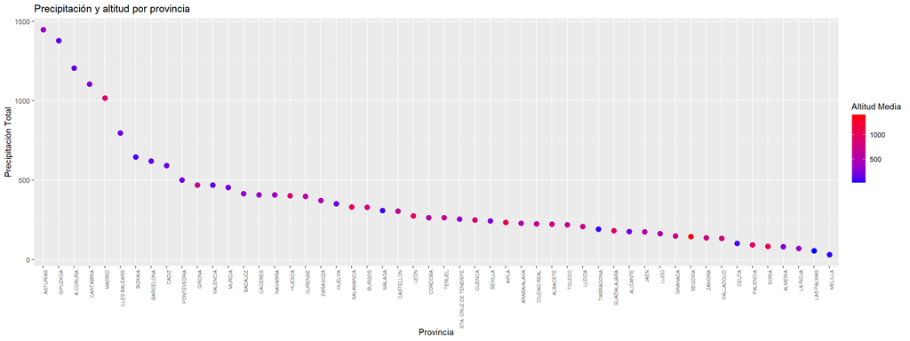

```r
ggplot(datos_grafico, aes(x = reorder(provincia,-precip_total), y = precip_total, color = altitu_media)) +
  geom_point(size = 3) +
  scale_color_gradient(low = "blue", high = "red") +
  labs(title = "Precipitación y altitud por provincia",
       x = "Provincia",
       y = "Precipitación Total",
       color = "Altitud Media") +
  theme(axis.text.x = element_text(angle = 90, hjust =1, size = 6))
```

El grafico anterior se muestran las precipitaciones del año 2020. Se puede observar que no hay una definida proporcionalidad directa entre altitud y cantidad de precipitaciones como se nos enseña desde siempre, ya que no es el unico factor influyente, tambien influye la porximidad al agua como se puede ver con las 4 porvincias que encabezan el grafico. La ubicación geográfica,los vientos dominantes, la topografía, la temperatura y los fenómenos climáticos son elementos que con un comportamiento en conjunto dificultan la prediccion de las precipitaciones de cada region. Es importante señalar que los impactos de la actividad humana en el clima y la precipitación son complejos y pueden causar grandes variaciones según la región.

### 4.5 Filtración de datos muertes con zonas verdes

```r
filtrado_resp<- inner_join(defuncion_resp_total, zonas_verdes, by = "Provincia")
datatable(filtrado_resp)
```

|  | Provincia | defunciones | Población | Parques m²/hab |
| --- | --- | --- | --- | --- |
| 1 | Albacete | 399 | 172816 | 7.16 |
| 2 | Alicante/Alacant | 1385 | 329988 | 6.12 |
| 3 | Almería | 518 | 195389 | 6.5 |
| 4 | Araba/Álava | 250 | 246976 | 26.76 |
| 5 | Asturias | 1215 | 272365 | 12 |
| 6 | Ávila | 228 | 161771 | 25.25 |
| 7 | Badajoz | 840 | 150543 | 6.75 |
| 8 | Balears, Illes | 734 | 1220739 | 1.451 |
| 9 | Barcelona | 4526 | 1620809 | 7 |
| 10 | Bizkaia | 832 | 345110 | 25.6 |

[output cut: 37 more lines]

#### Visualizacion del grafico de relación de zonas verdes y Defunciones por cada provincia

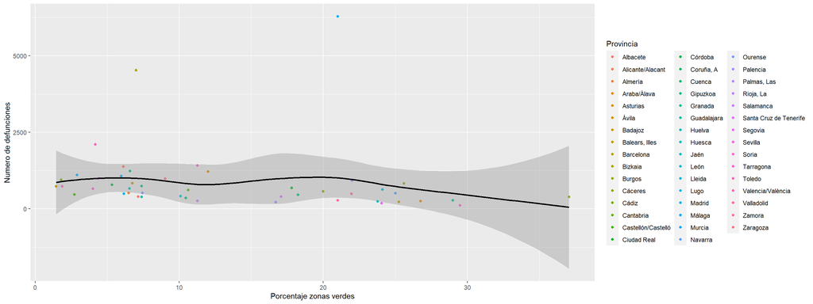

```r
ggplot(data = filtrado_resp, aes(x = `Parques m²/hab`, y =defunciones))+
  geom_point(aes(colour = Provincia))+
  geom_smooth(colour = "black")+#linea de tendencia
  labs(x = "Porcentaje zonas verdes", y = "Numero de defunciones")
```

Visualizando el grafico anterior, se puede ver la linea de tendencia a medida que aumenta el porcentaje de zonas verdes esta se mantiene algo constante pero apartir del 25% vemos que baja un poco, lo que podriamos deducir es que puede haber una ligera proporcionalidad inversa entre zonas verdes y la cantidad de defunciones en este año. Tambien cabe destacar las dos capitales nacionales, Barcelona y Madrid, que se muestran diferenciadas por su posicion en la parte alta del grafico dedbido a los altos numeros de defunciones donde se puede observar que ambas estan por debajo del punto critico de la linea de tendencia, 25%. Este grafico contrasta el porcentaje de zonas verdes respecto a la cantidad de defunciones anual pero no muestra una relacion muy clara entre ambas variables.

### 4.6 Filtración hospitales con la cantidad de zonas verdes

```r
datos_combinados <- inner_join(conteo_por_provincia, zonas_verdes, by = "Provincia")
datatable(datos_combinados)
```

|  | Provincia | Numero_Hospitales | Población | Parques m²/hab |
| --- | --- | --- | --- | --- |
| 1 | Albacete | 9 | 172816 | 7.16 |
| 2 | Alicante/Alacant | 23 | 329988 | 6.12 |
| 3 | Almería | 8 | 195389 | 6.5 |
| 4 | Araba/Álava | 6 | 246976 | 26.76 |
| 5 | Asturias | 25 | 272365 | 12 |
| 6 | Badajoz | 19 | 150543 | 6.75 |
| 7 | Balears, Illes | 24 | 1220739 | 1.451 |
| 8 | Barcelona | 136 | 1620809 | 7 |
| 9 | Bizkaia | 21 | 345110 | 25.6 |
| 10 | Burgos | 8 | 175623 | 37.06 |

[output cut: 36 more lines]

#### Gráfico de barras apiladas de nº de hospitales con cantidad de zonas verdes.

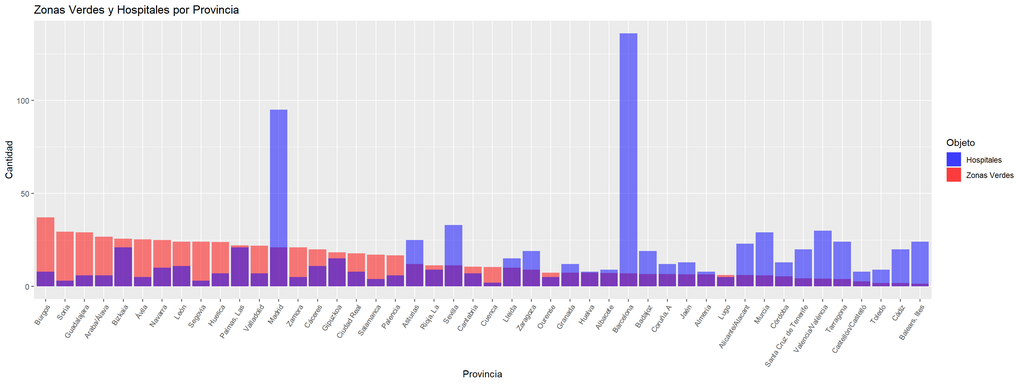

```r
ggplot(datos_combinados, aes(x = reorder(Provincia, -`Parques m²/hab` ))) +
  geom_bar(aes(y = `Parques m²/hab`, fill = "Zonas Verdes"), stat = "identity") +
  geom_bar(aes(y = Numero_Hospitales, fill = "Hospitales"), stat = "identity") +
  labs(title = "Zonas Verdes y Hospitales por Provincia",
       x = "Provincia",
       y = "Cantidad") +
  scale_fill_manual(name = "Objeto", values = c("Zonas Verdes" = alpha("red", 0.5), "Hospitales" = alpha("blue", 0.5))) +
  theme(axis.text.x = element_text(angle = 57, hjust = 1, size = 8))
```

El gráfico muestra la cantidad de hospitales y zonas verdes en diferentes provincias de España. Podemos observar que la provincia de Barcelona tiene el mayor número de hospitales, mientras que la provincia de Madrid ocupa el segundo puesto.

En cuanto a la relación entre el número de hospitales y zonas verdes, es importante tener en cuenta que estos dos factores pueden estar influenciados por una variedad de variables, como la densidad de población, el nivel de urbanización y el desarrollo económico de cada provincia.

Por ejemplo, las provincias con alta densidad de población y alto nivel de urbanización, como Madrid o Barcelona, pueden tener más hospitales debido a la mayor demanda de servicios de salud. Sin embargo, estas provincias también pueden tener menos zonas verdes debido a la falta de espacio disponible para parques y áreas recreativas.

Por otro lado, las provincias con menor densidad de población y menor nivel de urbanización, como algunas provincias rurales, pueden tener menos hospitales pero más zonas verdes debido a la abundancia de espacio natural, como lo son Soria o Burgos.

### 4.7 Grafica de relación de cantidad de muertes con la cantidad de hospitales

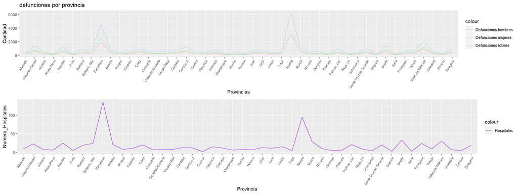

```r
union_muertes_gen_hosp<- inner_join(defuncion_resp_total, datos_combinados, by= "Provincia")
union_muertes_homb_hosp<-inner_join(defuncion_resp_hombres, datos_combinados,by= "Provincia")
union_muertes_mujer_hosp<-inner_join(defuncion_resp_mujeres,datos_combinados,by= "Provincia")
union_total<- inner_join(inner_join(union_muertes_gen_hosp, union_muertes_homb_hosp,by= c("Provincia" , "Población","Parques m²/hab","Numero_Hospitales") ), union_muertes_mujer_hosp,by= c("Provincia" , "Población","Parques m²/hab","Numero_Hospitales"))

g1<- ggplot(data = union_total, aes(x = Provincia )) +
  geom_line(aes(y = defunciones, group = 1, color="Defunciones totales")) +
  geom_line(aes(y = defunciones_mujeres, group = 2,color="Defunciones mujeres")) +
  geom_line(aes(y = defunciones_hombres, group = 4,color="Defunciones hombres")) +
  labs(title = "defunciones por provincia ",
       x = "Provincias",
       y = "Cantidad")+
  scale_color_manual(values = c("Defunciones totales" = "lightblue", "Defunciones mujeres" = "lightpink","Defunciones hombres" = "lightgreen"))+
  theme(axis.text.x = element_text(angle = 57, hjust = 1, size = 7))

g2<- ggplot(data = datos_combinados, aes(x = Provincia )) +
  geom_line(aes(y = Numero_Hospitales, group = 1,color="Hospitales")) +
   scale_color_manual(values = c("Hospitales" = "purple"))+
  theme(axis.text.x = element_text(angle = 57, hjust = 1, size = 7))

grid.arrange(g1, g2, nrow = 2)
```

Se puede observar como la cantidad de muertes y la cantidad de hospitales por provincias muestra una correlación aparente, en aquellas provincias con picos más altos en fallecidos existe a su vez picos altos en el número de hospitales y en aquellos con un número bajo de muertes existen también menor cantidad de hospitales. Debido a esto se puede afirmar que la cantidad de hospitales no interviene en el número de fallecidos, no por haber más cantidad de hospitales existen menos fallecidos.

### 4.8 Grafica de relación de cantidad de muertes con las precipitaciones

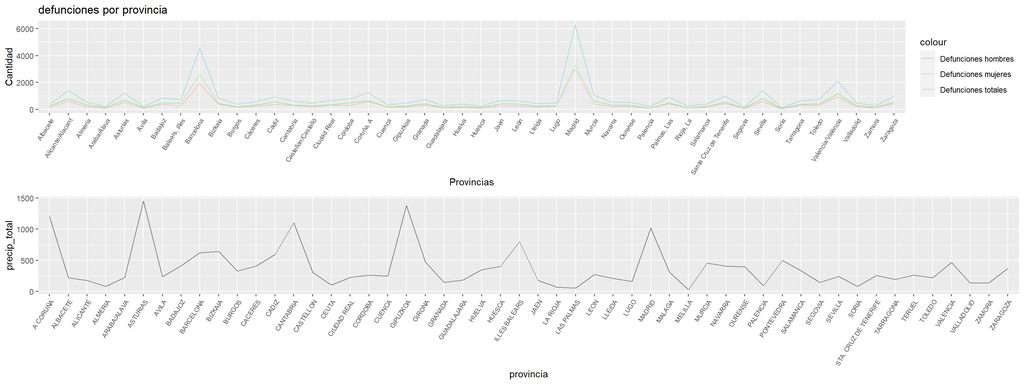

```r
g3<- ggplot(data = datos_grafico, aes(x = provincia )) +
  geom_line(aes(y = precip_total, group = 1,color="")) +
   scale_color_manual(values = c("Precipitaciones" = "blue"))+
  theme(axis.text.x = element_text(angle = 57, hjust = 1, size = 7))
grid.arrange(g1, g3, nrow = 2)
```

## Conclusiones finales

Analizados cada uno de los apartados, observamos que entre los tres factores existe una relación compleja donde cabe destacar la intrincada conexion entre los elementos y puede verse afectada por diversas influencias locales, que entre ellos se incluyen aspectos socioeconomicos, demograficos e infraestructurales, los cuales no hemos analizado, por lo cual no podemos sacar conclusiones de una relacción global.

Las áreas verdes, al ofrecer ventajas medioambientales y de bienestar, tienen el potencial de mejorar la salud global de la población como un aumento en la esperanza de vida, menor cantidad de enfermedades cardiovasculares y respratorias,mejor salud mental,Reducción de la mortalidad prematura, mejores funciones cognitivas en la infacia, asi como mejor salud en ancianos y bebes [2][3].

Las lluvias son beneficiosas tanto para el ser humano como para la biodiversidad y conservación de esta; en el ser humano ayuda tanto mentalmente como fisicamente, la lluvia hace que el aire se vuelva más limpio y purificado(eliminando contaminación y grandes cantidades de polen en suspensión), favoreciendo así la respiración de las personas. Estas también pueden plantear desafíos en cuanto a riesgos para la salud, como inundaciones y enfermedades vinculadas al agua. Por otro lado, se ha visto reflejado que el número de hospitales va asociado a la cantidad de población, pero no por esto se producen mas defunciones ya que la cantidad de defunciones también va acompañada a la cantidad de población, con lo cuál se puede concluir que el número de hospitales es una herramienta util para desglosar este acontecimiento pero a su vez no hay una correlación grande entre ellas.

## Bibliografia

[1] https://maldita.es/clima/20221219/lluvia-reduce-contaminacion-atmosferica-cuanto/

[2] https://www.isglobal.org/healthisglobal/-/custom-blog-portlet/why-more-green-space-is-essential-for-cities#:~:text=Los%20espacios%20verdes%20est%C3%A1n%20asociados,mayores%2C%20y%20beb%C3%A9s%20m%C3%A1s%20sanos. [3] https://es.greenpeace.org/es/noticias/regla-3-30-300-ciudades-verdes/